# JavaScript

- interpreting programming language
- runs in client server
- object-oriented language

## 1. Three types using JavaScript

#### internal style

`<script>`  
`// Your JavaScript`  
`</script>`

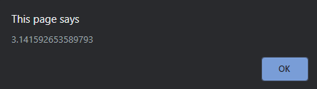

```
<script>
    alert(Math.PI)
</script>
```

#### external style

`<script src='yourScript.js'></script>`

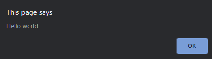

- In `.html`

```
<script src="js/main.js"></script>
```

- In `.js`

`alert('Hello ' + 'world');`

#### function style

`<button`  
`onclick = 'createParagraph()'>`  
`</button>`

## 2. String in JavaScript

- find the length of a string
  - `console.log('hello'.length);`
- access elements by their index
  - `console.log('hello'.charAt(0));`
- replace characters
  - `console.log('hello, world'.replace('hello','goodby'));`
- to upper case
  - `console.log('hello, world'.toUpperCase())`
- The output

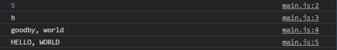

## 3. Bool in JavaScript

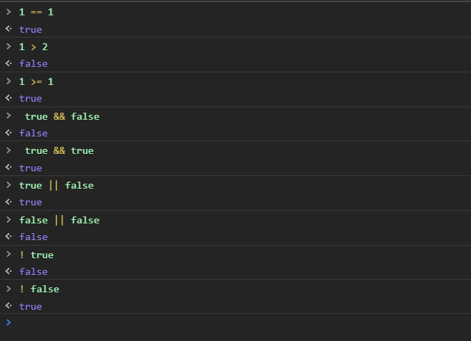

## 4. Variables in JavaScript

- using `var`
- using `let`
- using `const`

```
var name = 'DasAuto';
console.log(name);
name = 'Simon';
console.log(name)
let a = 1;
console.log(a);
```

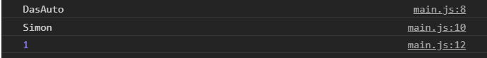

### constant variable in JavaScript

- once give a value to it, can not be changed anymore.

```
const Pi = 3.14;
console.log(Pi);
Pi = 3.14159;
console.log(Pi)
```

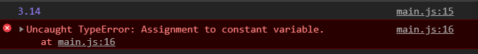

### Scope of variables in JavaScript

- `var` creates global variables
- `let` and `const` creates local variables

```
var a = 19;

if (true) {
    var b = 20;
}

if (true) {
    let c = 21;
}

do {
    a++;
    console.log(a)
} while (a<= b);

do {
    b++;
    console.log(b)
} while (b<= c);
```

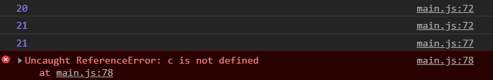

## 5.Operation in JavaScript

#### 5.1 Arithmetic operation in JavaScript

```
var x = 5;

console.log(x);

x += 5;
console.log(x);

x++;
console.log(x);

x--;
console.log(x);
```

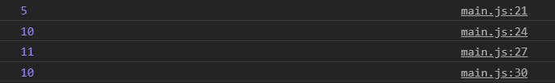

#### 5.2 In JavaScript, using `+` to connect one string with one numeric variable are allowed.

```
var x;

x = '3' + 4 + 5; // x = '3' + '4' + '5'
console.log(x);

x = 3 + 4 + '5'; // x = 3 + 4 then x = '7' + '5'
console.log(x);
```

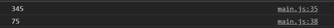

#### 5.3 `==` and `===` in JavaScript

- `==` would do the type transformation automatically
- `===` would do not do the type transformation

```
console.log(123 == '123'); // '123' '123'
console.log(123 === '123');
```

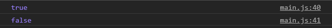

## 6.Flow control in JavaScript

### 6.1 `if`

```
var name = 'Daniel';
var age = 20;
if (name == 'Simon' && age == 21) {
    console.log('Simon');
} else  if (name == 'John'){
    console.log('John');
} else {
    console.log('Stranger!');
}
```

### 6.2 `while` and `do while` loop

- `do while` loop would be excuted at least one time
- both rely on the condition status

```
var a = 19;
var b = 20;
var i = 0;
while ((a +i) <= b) {
    console.log('true')
    i++;
}

do {
    a++;
    console.log(a)
} while (a<= b);
```

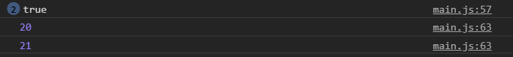

### 6.3 `for` loop

- similar to Java

```
for(let i = 0; i<=5; i++) {
    console.log(i)
}
```

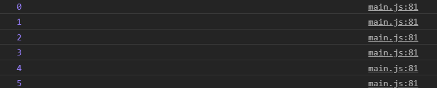

### 6.4 Ternary operation

```
var age = 20;
var allowed = age >=18 ? 'Yes' :'NO';
console.log(allowed);
```

### 6.5 `Switch` in JavaScript

```
var name = 'Daniel';

switch(name) {
    case 'Simon':
        console.log("It's Simon");
        break;
    case 'John':
        console.log("It's John");
        break;
    default:
        console.log("It's a stranger");
}
```

## 7. `object` in JavaScript

- using `new Object()` to create
- using `{}` to create
- json

```
var obj = new Object();
var obj2 = {};
obj = {
    name: 'Simon',
    age:'20',
    email:'simon@gmail.com',
    contact: {
        phone : '2134567',
        telegram: '@Simon'
    }
};

console.log(obj);
```

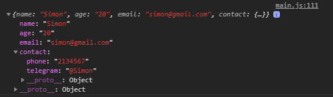

- similar to `dict` in Python

```
console.log(obj.contact.phone);
console.log(obj['contact']['phone']);
```

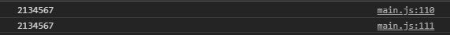

#### Add properties

```
obj.contact.wechat = 'abcd';
console.log(obj.contact)
```

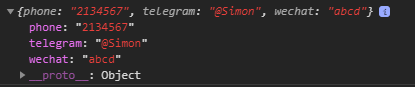

## 8. `Arrary` in JavaScript

- similar to list in Python
- need to initialize
- could contain `empty`

```
var a = new Array();
var b = [];
a[0] = 'dog';
a[1] = 'cat';
a[5] = 'tiger';
console.log(a);
console.log(a[2]);
```

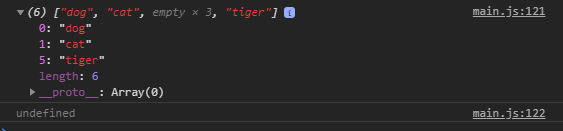

### Traverse array

```
b = ['dog', 'cat', 'tiger'];

for (let i = 0; i < b.length; i++){
    console.log(b[i]);
}
```

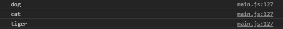

#### we could also use `for in` loop, but would ignore the `empty`

```
for(let i in a){
    console.log(a[i]);
}
```

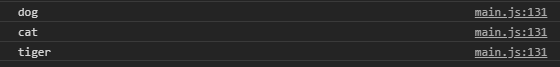

### Function in array

- `push`, same to `append`
- `pop`
- `shift`: delete the first element
- `unshift`: add elements as the first position in array
- `reverse`

```
b = ['dog', 'cat', 'tiger'];
b.push('sheep');
b.unshift('lion');
console.log(b);
```

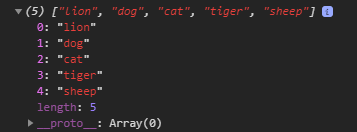

## Functions in JavaScript

- use keyword `function` to create a function
- use `arguments` to get the inputs

```
function add() {
    let sum = 0;
    for(let i = 0,j = arguments.length; i<j;i++){
        sum += arguments[i];
    }
    return sum;
}

let sum = add(1,2,3,4,5,6,7,8,9,10);
console.log(sum);
```